# time_series_cross_validation

### Introduction time series cross-validation

Complex time series forecasting methods like ARIMA pose special challenges for fitting and model evaluation. We must be careful when using AIC/BIC/AICc to make sure the log-likelihoods are evaluated on the **same** sample sizes for all models. Not all specialized modeling functions support such approaches however. We resorted to a single train/test split to identify the best model. However, a single train/test split is just a single comparison. You may have wondered **why** the data were split at a particular point in time. What if a **different** point in time was used to define the training and test sets? Would the model rankings change? Essentially, how **robust** is our model selection to the choice of training and test data? We **cannot** answer such a question on a single train/test split!

We therefore need to **repeat the splitting** multiple times. The final performance assessment can thus be made by averaging across all splits. We learned about **K-fold cross-validation** in CMPINF 2120 as one such **Resampling** procedure. However, we cannot apply "regular" K-fold cross-validation for time series problems. The hold-out data **must** always be in the future! Regular K-fold cross-validation randomly select the test points and thus there is a chance the hold-out data are in the past! Predicting the past is easy compared to the future!

Thus, time series cross-validation is a special way of implementing cross-validation. It ensures all hold-out test set data are in the future. Time series cross-validation is **NOT** random, as you will see the splits are created by "sweeping" over the entire data set in time.

This notebook demonstrates the core concepts of time-series cross-validation on a synthetic data example. This allows us to focus on how the data are split, rather than being concerned with the fitting of the models.

## Import Modules

```python
import numpy as np
import pandas as pd
import matplotlib.pyplot as plt

import seaborn as sns
```

## Synthetic data example

Generate a random walk by adding into integer steps randomly selected as -1 or +1. Initialize the random number generator.

```python
rg = np.random.default_rng( 2120 )
```

Specify the number of steps in the sequences.

```python
num_steps = 200
```

Randomly generate a step in the -1 or +1 direction, calculate the running sum of the steps.

```python
x = rg.choice([-1, 1], size=num_steps, replace=True).cumsum()
```

Package together into a DataFrame.

```python
x_df = pd.DataFrame({'x': x})
x_df['step_id'] = x_df.index + 1
```

```python
x_df
```

|  | x | step_id |
| --- | --- | --- |
| 0 | 1 | 1 |
| 1 | 0 | 2 |
| 2 | 1 | 3 |
| 3 | 2 | 4 |
| 4 | 1 | 5 |
| ... | ... | ... |
| 195 | 4 | 196 |
| 196 | 5 | 197 |
| 197 | 6 | 198 |
| 198 | 7 | 199 |
| 199 | 8 | 200 |

200 rows × 2 columns

Visualize the synthetically generated data below. The "time" in this simple example is the `step_id` variable. Thus, the "time" is increasing from 1 to 200.

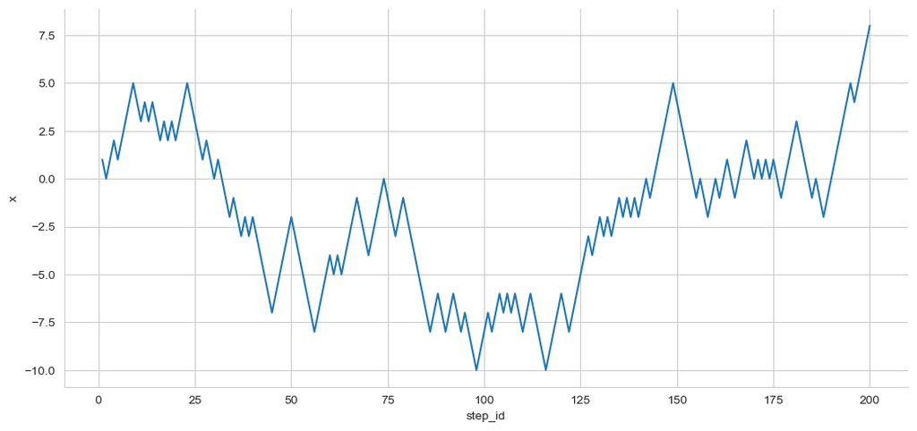

```python
sns.set_style('whitegrid')

sns.relplot(data = x_df, x='step_id', y='x', kind='line', aspect = 2.1)

plt.show()
```

### Create the time-series splits

Import the time series cross-validation method from `sklearn`.

```python
from sklearn.model_selection import TimeSeriesSplit
```

Let's use 5 folds and see what happens.

```python
tscv05 = TimeSeriesSplit(n_splits=5)
```

Define a function which extracts the training and test splits within each fold. The splits are stored within DataFrames to make it easier to plot with Seaborn. The function below consists of two separate for-loops. The first one loops over the folds and extracts the training and test data points in each fold. The second for-loop is used to add in the fold index. Then all training/test splits across all folds are combined into a single DataFrame. We used a procedure like this in CMPINF 2100 when we starting working with cross-validation.

```python
def extract_ts_folds(df, cv):
    res_list = []

    # combine the training and test splits in each fold
    for train_id, test_id in cv.split(df.to_numpy()):
        train_df = df.iloc[train_id, :].copy()
        train_df['split_name'] = 'training'

        test_df = df.iloc[test_id, :].copy()
        test_df['split_name'] = 'testing'

        res_list.append( pd.concat([train_df, test_df]) )

    # assign the fold id
    for i, res in enumerate( res_list ):
        res['fold_id'] = i

    # combine all folds together
    res_df = pd.concat( res_list )

    return res_df
```

Apply the function for our synthetic data set and 5 fold time series object.

```python
sim_ts_folds = extract_ts_folds( x_df, tscv05 )
```

The glimpse of the DataFrame is shown below.

```python
sim_ts_folds
```

|  | x | step_id | split_name | fold_id |
| --- | --- | --- | --- | --- |
| 0 | 1 | 1 | training | 0 |
| 1 | 0 | 2 | training | 0 |
| 2 | 1 | 3 | training | 0 |
| 3 | 2 | 4 | training | 0 |
| 4 | 1 | 5 | training | 0 |
| ... | ... | ... | ... | ... |
| 195 | 4 | 196 | testing | 4 |
| 196 | 5 | 197 | testing | 4 |
| 197 | 6 | 198 | testing | 4 |
| 198 | 7 | 199 | testing | 4 |
| 199 | 8 | 200 | testing | 4 |

670 rows × 4 columns

The concatenated splits object `sim_ts_folds` has more rows than our original data set. Let's visualize the training/test splits in each fold to understand just why that is. The figure below uses separate facets for each fold. The blue line is the training set within the fold and the orange line is the test set with the fold.

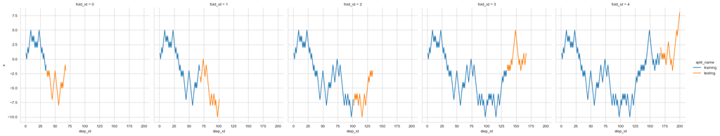

```python
sns.relplot( data = sim_ts_folds, x='step_id', y='x', hue='split_name', kind='line', col='fold_id' )

plt.show()
```

As we can see above, the 0th fold has the least amount of data for training. The 0th fold's training set is the earliest portion of the data. However, the test set is **NOT** the entire remaining time series. The test set or **forecast horizon** is the immediate next interval of the data. Each fold "rolls" the testing forecast horizon, thereby adding the previous fold's test set to the training set. The training set grows in size as we move across the folds, to represent we are collecting more data as we move forward in time. Each subsequent fold tests on the immediate future interval of data, and thus represents checking performance on "future data".

Let's confirm the size of the training and test splits in each fold.

```python
sim_ts_folds.groupby(['fold_id', 'split_name']).size().reset_index(name='num_rows').\
pivot(index='fold_id', columns='split_name', values='num_rows')
```

| split_name fold_id | testing | training |
| --- | --- | --- |
| 0 | 33 | 35 |
| 1 | 33 | 68 |
| 2 | 33 | 101 |
| 3 | 33 | 134 |
| 4 | 33 | 167 |

As we see above, each fold's test split has 33 data points. The training set in fold 0 is 35. The training set in fold 1 is 35 plus the number of test points in fold 0 (33), and therefore equals $35 + 33 = 68$. The training set keeps growing in increments of 33 until the end of the cross-validation process.

The fold test sets consisted of 33 observations because the default test set size is calculated as:

$$ \frac{N}{K + 1} $$

where $N$ is the total number of data points and $K$ is the number of folds.

For our example, we have 200 points and 5 folds, thus:

```python
200 / (5 + 1)
```

```
33.333333333333336
```

Since the result is not a whole number, the number of test points is rounded down to the nearest integer giving us 33 test points per fold.

### Training set size modification

We are free to set the maximum allowable training set size when we create the time series splits. Let's see what happens if we choose a max training set of 50 points, while still using 5 folds.

```python
tscv05_b = TimeSeriesSplit(n_splits=5, max_train_size=50)
```

```python
sim_ts_folds_b = extract_ts_folds( x_df, tscv05_b )
```

The training and test splits are visualized across the folds below.

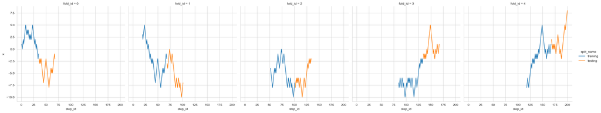

```python
sns.relplot( data = sim_ts_folds_b, x='step_id', y='x', hue='split_name', kind='line', col='fold_id' )

plt.show()
```

By capping the maximum training set size, only the "most recent data" is used for training in each fold. Once the maximum size is reached, the older data points are discarded. This can be useful if you know you do not want older data to continually stay in the model. Such situations may occur if you know there are "structural changes" to the data over time. A "structural change" can represent a change in policy from the government that impacts the variable you are interested in. Or, perhaps you are working on a sports related application and there is a rule change. The old data before the rule change may not be as relevant to forecasting future behavior after the rule change.

The cell below confirms that once the training set maximum size is reached, it stays constant across the folds.

```python
sim_ts_folds_b.groupby(['fold_id', 'split_name']).size().reset_index(name='num_rows').\
pivot(index='fold_id', columns='split_name', values='num_rows')
```

| split_name fold_id | testing | training |
| --- | --- | --- |
| 0 | 33 | 35 |
| 1 | 33 | 50 |
| 2 | 33 | 50 |
| 3 | 33 | 50 |
| 4 | 33 | 50 |

### Test set size modification

The `TimeSeriesSplit` function includes several other arguments. The `test_size` argument allows us to limit the test set size and thus change from the default behavior. For example, instead of forecasting 33 future steps at a time, perhaps we only interested in 10 future steps. We may thus limit the forecast horizon in anticipation of struggling to forecast behavior too far into the future.

Let's first try this out by accumulating the training set overtime and forecasting 10 future steps.

```python
tscv05_c = TimeSeriesSplit(n_splits=5, test_size=10)
```

Extract the training and test sets.

```python
sim_ts_folds_c = extract_ts_folds( x_df, tscv05_c )
```

Visualizing the training and test sets reveals the number of training points is VERY different from our original splits!

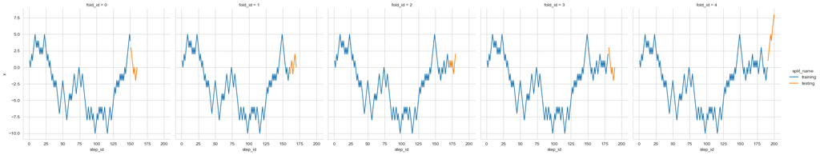

```python
sns.relplot( data = sim_ts_folds_c, x='step_id', y='x', hue='split_name', kind='line', col='fold_id' )

plt.show()
```

Let's directly compare the original time series split with the new test set size modified split. The `test_size` value is associated with the row facets in the figure below. This reveals that the `test_size` **impacts** the end of the 0th fold's training set! Smaller test set sizes focus on examining the **most recent** data!!!

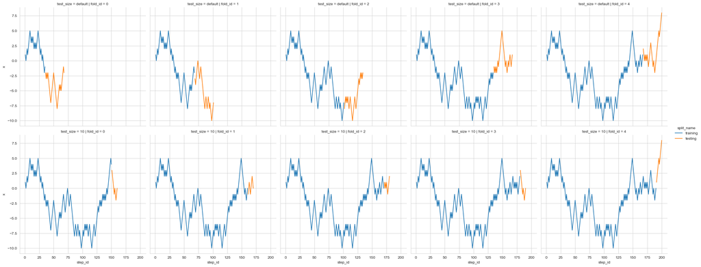

```python
sns.relplot(data = pd.concat([sim_ts_folds, sim_ts_folds_c], axis=0, keys=['default', '10']).reset_index(names=['test_size', 'index']),
            x='step_id', y='x',
            hue='split_name',
            col='fold_id', row='test_size',
            kind='line')

plt.show()
```

Let's now combine limiting the max training set size and reducing the test set size. The time series cross-validation object defined below uses the max training set size of 50 and the test set size of 10.

```python
tscv05_d = TimeSeriesSplit(n_splits=5, max_train_size=50, test_size=10)
```

Extract the training and test sets.

```python
sim_ts_folds_d = extract_ts_folds( x_df, tscv05_d )
```

Visualize the training and test sets.

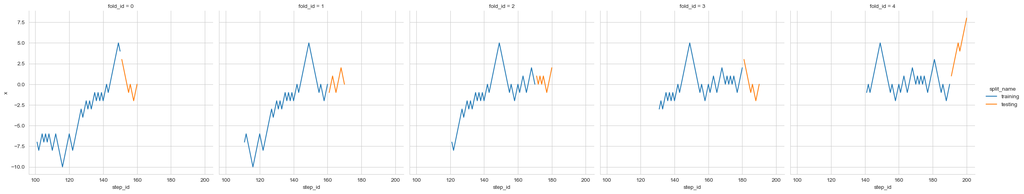

```python
sns.relplot( data = sim_ts_folds_d, x='step_id', y='x', hue='split_name', kind='line', col='fold_id' )

plt.show()
```

The above facets reveal the start and end of the fold's training sets are different compared to the previous version that only limited the training set size. The figure below directly compares the two different approaches with max training set size of 50. The top facet row uses the default `test_size` value while the bottom facet row uses the smaller `test_size` value of 10. As before, reducing the test size forces the training set to focus on the more recent points of time.

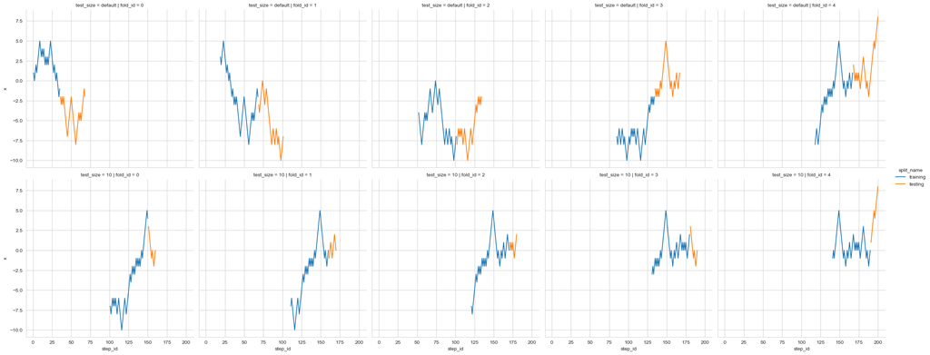

```python
sns.relplot(data = pd.concat([sim_ts_folds_b, sim_ts_folds_d], axis=0, keys=['default', '10']).reset_index(names=['test_size', 'index']),
            x='step_id', y='x',
            hue='split_name',
            col='fold_id', row='test_size',
            kind='line')

plt.show()
```

Limiting the max training set size prevents the oldest data from being used in the models. The figure below directly compares the folds between the two situations that use `test_size = 10`. Thus, the figure below compares the default `max_train_size` to the limited `max_train_size = 50`.

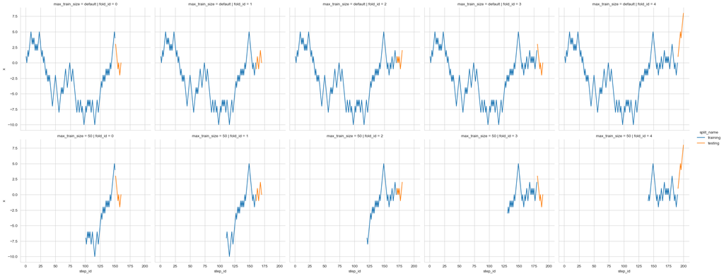

```python
sns.relplot(data = pd.concat([sim_ts_folds_c, sim_ts_folds_d], axis=0, keys=['default', '50']).reset_index(names=['max_train_size', 'index']),
            x='step_id', y='x',
            hue='split_name',
            col='fold_id', row='max_train_size',
            kind='line')

plt.show()
```

## Summary

In conclusion, we want to ensure the hold-out test set within each fold is **always** future data with time series cross-validation. This notebook demonstrated the training set size is impacted by the `max_train_size` and `test_size` arguments to `TimeSeriesSplit()`. Reducing the default `test_size` argument focuses testing behavior on more recent data.